# Project: Communicate Data Findings

### By: Krutarth Darji

## Getting insight of the Dataset

## What is Structure of the data

> Data has 519700 rows and 15 columns, from June'17 to December'17

## What is/are the main feature(s) of interest in your dataset?

> I'm most interested in figuring out distribution of various variables like age,duration,start/end time etc and relationship among the variables through creating visualizations

# Univariate Exploration

### Question 1. Distribution of Age of the members

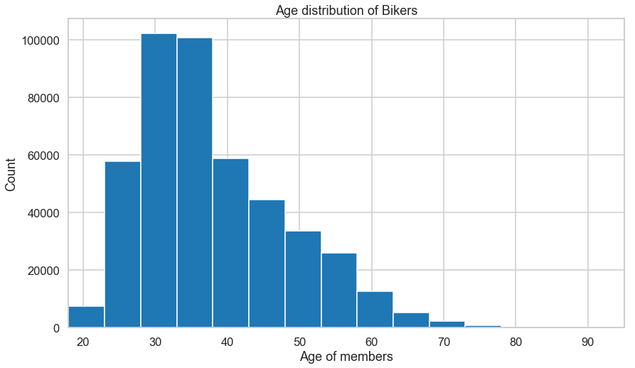

```python
plt.figure(figsize=[14,8])
plt.hist(data=fgb,x='member_age',bins=np.arange(18,95+5,5));
plt.xlabel('Age of members')
plt.ylabel('Count')
plt.title('Age distribution of Bikers')
plt.xlim(18,95);
```

### Answer

> Maximum number of members are below the age of 80 and most the members are having ages 30-40

### Question 2. Gender Distribution of the dataset

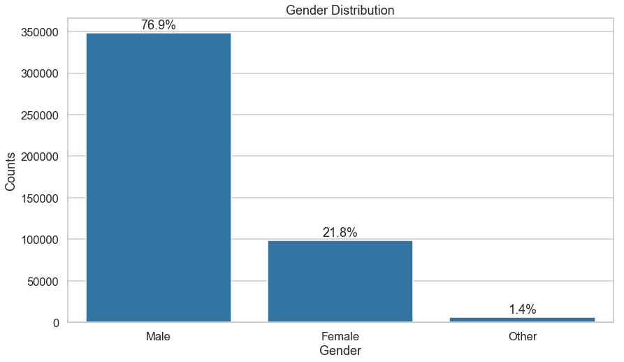

```python
plt.figure(figsize=[14,8])
order1=fgb_sub['member_gender'].value_counts().index
sb.countplot(data=fgb_sub,x='member_gender',order=order1,color=sb.color_palette()[0])
plt.xlabel('Gender')
plt.ylabel('Counts')
plt.title('Gender Distribution')
order2=fgb_sub['member_gender'].value_counts()
for i in range (order2.shape[0]):
    count=order2[i]
    strt='{:0.1f}%'.format(100*count / fgb_sub.shape[0])
    plt.text(i,count+5000,strt,ha='center')
```

### Answer:

> Above figure shows the gender distribution clearly by showing the proportions as well as counts

### Question 4. Find most commonly used end stations

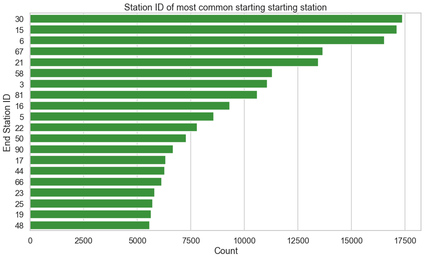

```python
plt.figure(figsize=[14,8])
sb.countplot(data=fgb_sub2,y='end_station_id',order=arr2.index,color=sb.color_palette()[2]);
plt.ylabel('End Station ID')
plt.xlabel('Count')
plt.title('Station ID of most common starting starting station')
```

### Answer:

> Above figure shows the most common end station on the vertical axis and their number of occurence on the horizontal axis

### Question 5. Month wise distribution of the Rented bikes

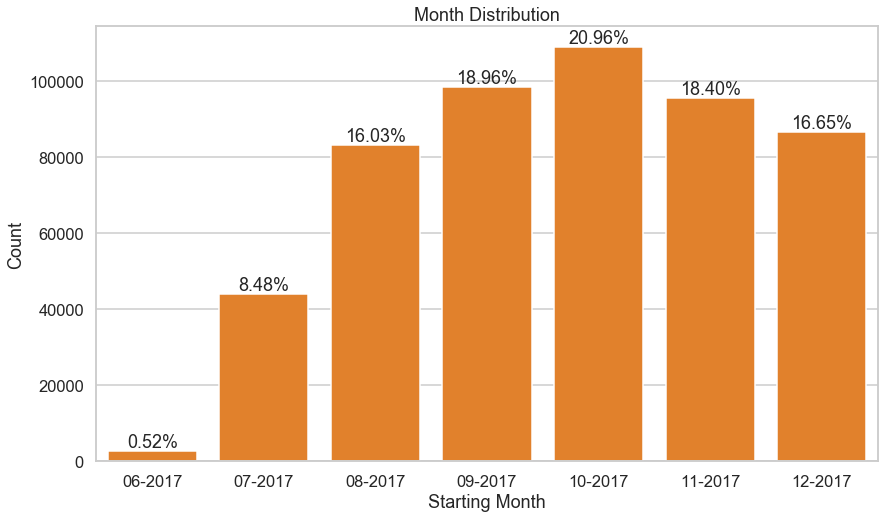

```python
plt.figure(figsize=[14,8])
sb.barplot(data=fgb_sub3,x=fgb_sub3.index,y='bike_id',color=sb.color_palette()[1]);
plt.xlabel('Starting Month')
plt.ylabel('Count')
plt.title('Month Distribution')
for i in range(fgb_sub3.shape[0]):
    count=fgb_sub3.iloc[i]['bike_id']
    strt='{:0.2f}%'.format(100*count/fgb.shape[0])
    plt.text(i,count+1000,strt,ha='center')
```

### Answer:

> Above figure clearly describes the month wise distribution of the rented bikes, showing proportion as well as total count

### Question 6. Start time Distribution of the rented bikes

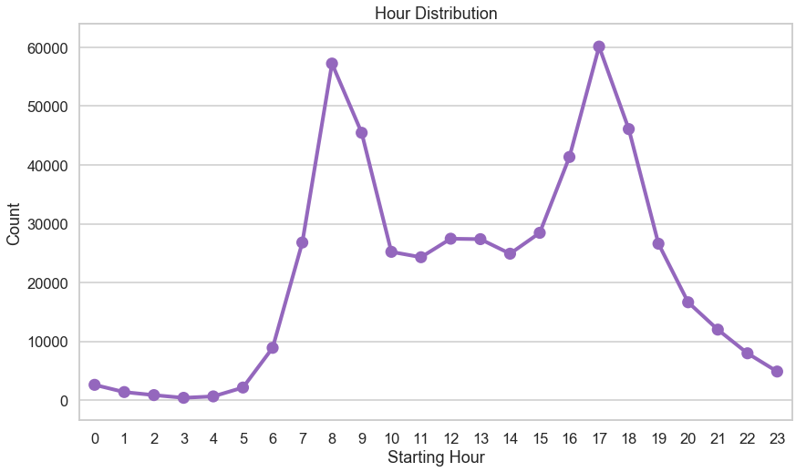

```python
plt.figure(figsize=[14,8])
sb.pointplot(data=fgb_sub4,x=fgb_sub4.index,y='bike_id',color=sb.color_palette()[4]);
plt.xlabel('Starting Hour')
plt.ylabel('Count')
plt.title('Hour Distribution')
```

### Answer:

> Above plt shows that start hour 8 and 17 are most used and least used start hours are 2,3 and 4

### Question 7. End time Distribution of the rented bikes

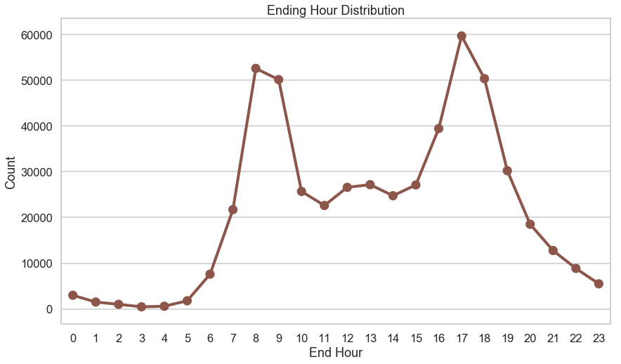

```python
plt.figure(figsize=[14,8])
sb.pointplot(data=fgb_sub5,x=fgb_sub5.index,y='bike_id',color=sb.color_palette()[5]);
plt.xlabel('End Hour')
plt.ylabel('Count')
plt.title('Ending Hour Distribution')
```

### Answer:

> Above plt shows that end hour 8,9 and 17 are most used and least used start hours are 2,3 and 4

### Question 8. Starting days distribution for the rented bikes

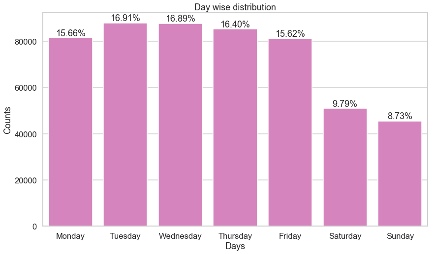

```python
plt.figure(figsize=[14,8])
sb.barplot(data=fgb_sub6,x='start_time_weekday',y='duration_sec',color=sb.color_palette()[6]);
plt.title('Day wise distribution');
plt.xlabel('Days')
plt.ylabel('Counts')
for i in range(fgb_sub6.shape[0]):
    arr3=[1,5,6,4,0,2,3]
    j=arr3[i]
    count=fgb_sub6.iloc[j]['bike_id']
    strt='{:0.2f}%'.format(100*count/fgb.shape[0])
    plt.text(i,count+1000,strt,ha='center')
```

### Answer:

> Above plot shows the distribution of rented bikes with respect to the weekday, on saturday and sunday less number of bikes are rented.

### Question 9. Distribution of the duration of journey from the member

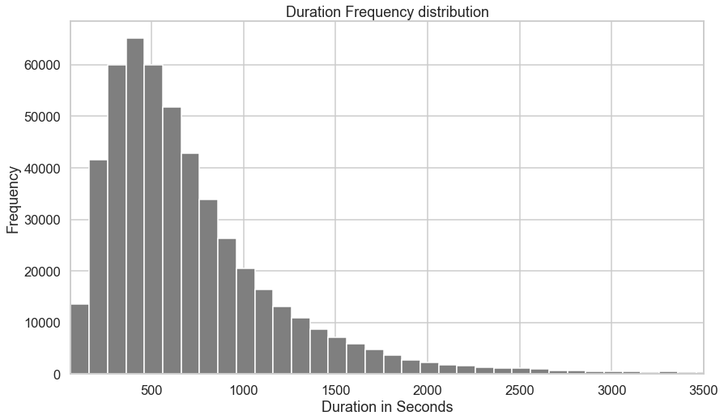

```python
plt.figure(figsize=[14,8])
plt.hist(data=fgb,x='duration_sec',bins=np.arange(60,3500+100,100),color=sb.color_palette()[7])
plt.xlim(60,3500)
plt.xlabel('Duration in Seconds');
plt.ylabel('Frequency');
plt.title('Duration Frequency distribution');
```

### Answer:

> Above plot shows that most of the journeys are less than 2000 seconds, most common journey are 260-460 seconds

### Question 10. Distribution according to the user type

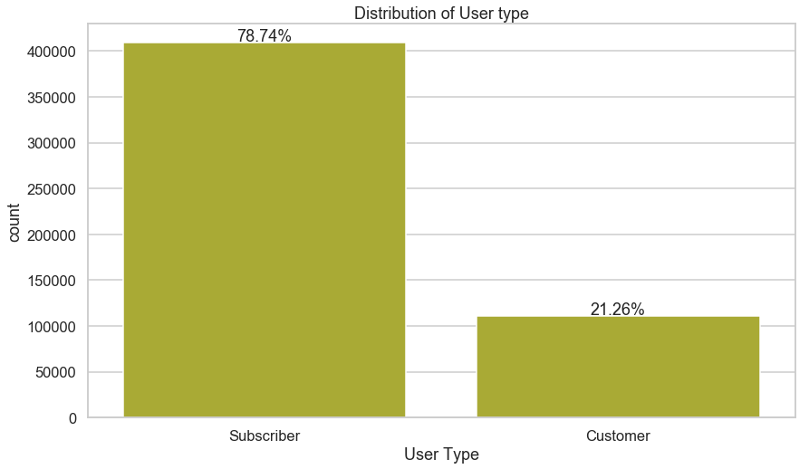

```python
plt.figure(figsize=[14,8])
sb.countplot(data=fgb,x='user_type',order=['Subscriber','Customer'],color=sb.color_palette()[8])
for i in range(fgb['user_type'].value_counts().shape[0]):
    count=fgb['user_type'].value_counts()[i]
    strt='{:0.2f}%'.format(100*count/fgb.shape[0])
    plt.text(i,count+2000,strt,ha='center')
plt.xlabel('User Type');
plt.title('Distribution of User type');
```

### Answer:

> plot shows distribution according to the user type, Subscriber user type is around 80% and customer user type is around 20%.

### Question 11. Age Group distribution in the dataset.

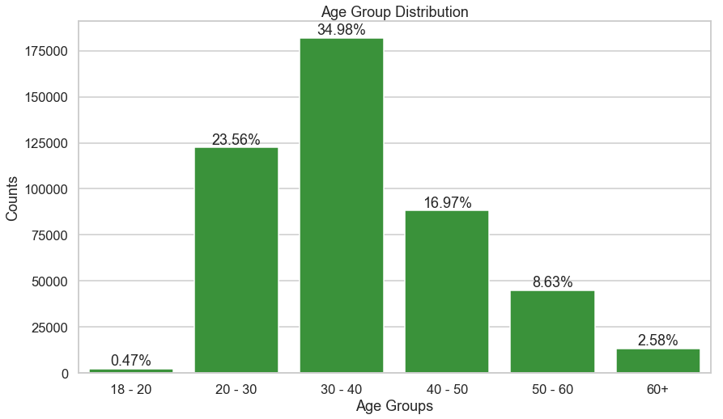

```python
plt.figure(figsize=[14,8])
sb.barplot(data=fgb_sub7,x=fgb_sub7.index,y='bike_id',color=sb.color_palette()[2]);
plt.xlabel('Age Groups');
plt.ylabel('Counts');
plt.title('Age Group Distribution');
for i in range (fgb_sub7.shape[0]):
    count=fgb_sub7.iloc[i]['bike_id']
    strt='{:0.2f}%'.format(100*count/fgb.shape[0])
    plt.text(i,count+2000,strt,ha='center')
```

### Answer:

> Plot shows that most number of users are from the age group 20-40

## Bivariate Plots

### Question 12. Relationship between Gender and Duration of the journey.

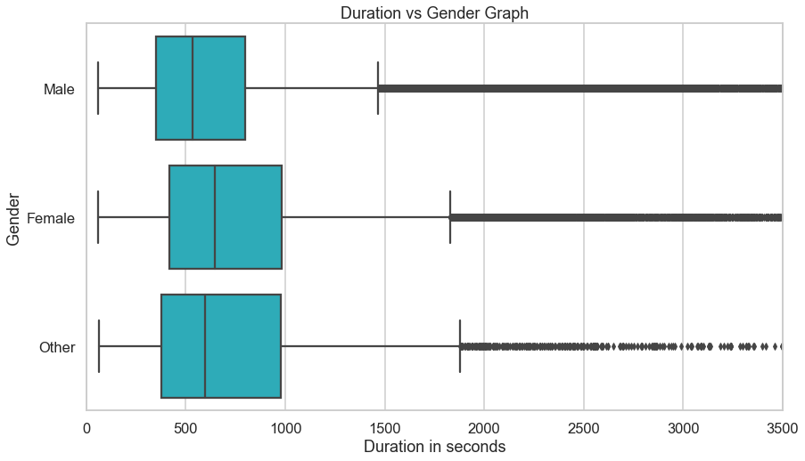

```python
plt.figure(figsize=[14,8])
sb.boxplot(data=fgb,y='member_gender',x='duration_sec',color=sb.color_palette()[9]);
plt.xlim(0,3500)
plt.xlabel('Duration in seconds');
plt.ylabel('Gender')
plt.title('Duration vs Gender Graph');
```

### Answer:

> Above plot shows us that we have huge number of outliers in all three genders and mean duration of female gender is highest.

### Question 13. Relationship between user type and duration

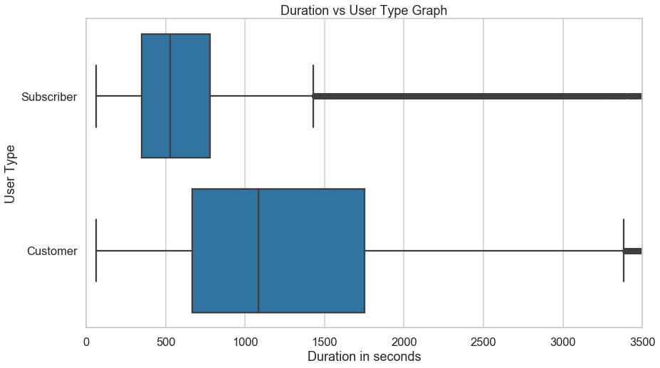

```python
plt.figure(figsize=[14,8])
sb.boxplot(data=fgb,y='user_type',x='duration_sec',color=sb.color_palette()[0]);
plt.xlim(0,3500)
plt.xlabel('Duration in seconds');
plt.ylabel('User Type');
plt.title('Duration vs User Type Graph');
```

### Answer:

> Huge number of outliers are observed in both categories however customer user type member usually takes more longer journey with respect to duration.

### Question 14. Trends of starting hour of the user types.

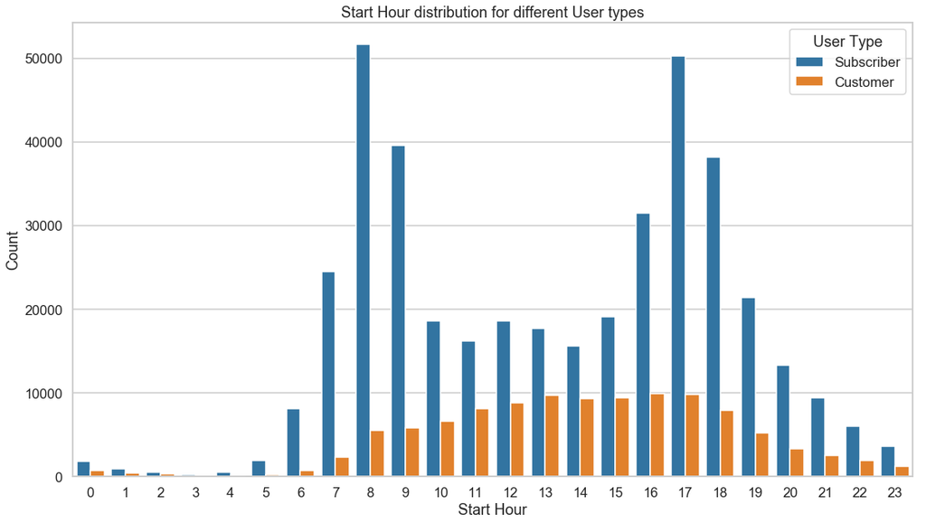

```python
plt.figure(figsize=[18,10])
sb.countplot(data=fgb,x='start_hour',hue='user_type');
plt.legend(title='User Type');
plt.xlabel('Start Hour');
plt.ylabel('Count');
plt.title('Start Hour distribution for different User types');
```

### Answer:

> Above plot shows that most used start hour for Subscribers is 8 and 5 while for the customers start hour frequency increases from 6-17 and then starts decrerasing

### Question 15. Trends of start hour with respect to gender.

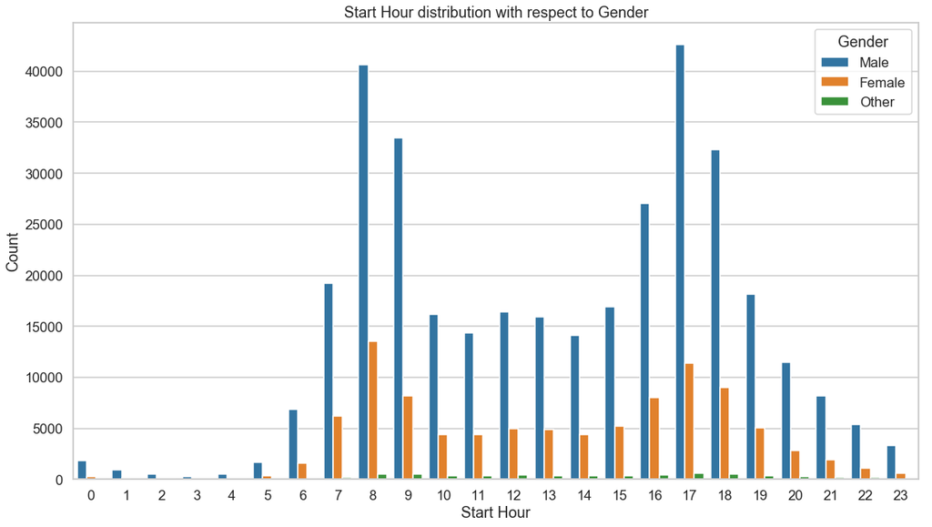

```python
plt.figure(figsize=[18,10])
sb.countplot(data=fgb,x='start_hour',hue='member_gender');
plt.legend(title='Gender');
plt.xlabel('Start Hour');
plt.ylabel('Count');
plt.title('Start Hour distribution with respect to Gender');
```

### Question 16. Trends between Start hour and Duration of the journey.

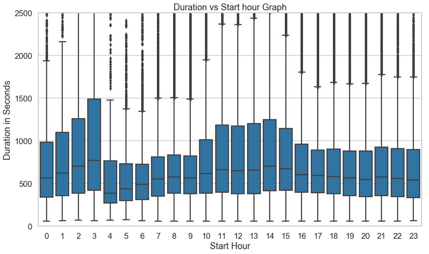

```python
plt.figure(figsize=[14,8])
sb.boxplot(data=fgb,x='start_hour',y='duration_sec',color=sb.color_palette()[0]);
plt.ylim(0,2500)
plt.xlabel('Start Hour');
plt.ylabel('Duration in Seconds');
plt.title('Duration vs Start hour Graph');
```

### Question 17. Trends between Start month and age group.

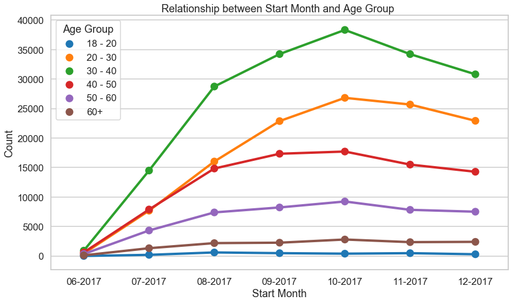

```python
plt.figure(figsize=[14,8])
sb.pointplot(data=fgb_sub8,x='start_month_year',hue='member_age_bins',y='bike_id');
plt.legend(title='Age Group');
plt.title('Relationship between Start Month and Age Group ');
plt.xlabel('Start Month');
plt.ylabel('Count');
```

### Question 18. Trends between different user type and start month

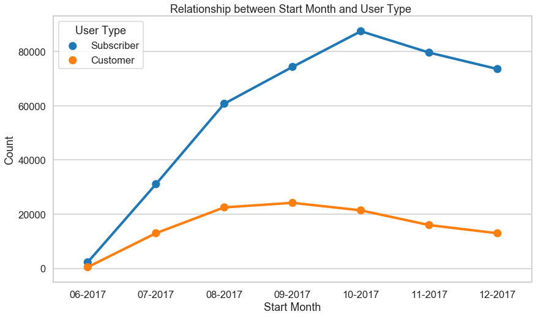

```python
plt.figure(figsize=[14,8])
sb.pointplot(data=fgb_sub9,x='start_month_year',hue='user_type',y='bike_id');
plt.legend(title='User Type');
plt.title('Relationship between Start Month and User Type ');
plt.xlabel('Start Month');
plt.ylabel('Count');
```

## Multivariate Plots

### Question 19. Trends between start day and duration for the different gender

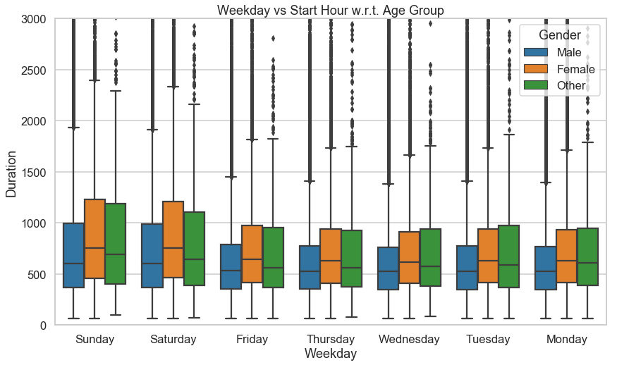

```python
plt.figure(figsize=[14,8])
sb.boxplot(data=fgb,y='duration_sec',x='start_time_weekday',hue='member_gender');
plt.xlabel('Weekday');
plt.ylabel('Duration');
plt.ylim([0,3000])
plt.title('Weekday vs Start Hour w.r.t. Age Group');
plt.legend(title='Gender',loc=1)
```

### Question 20. Trends between start hour and duration for the different user type

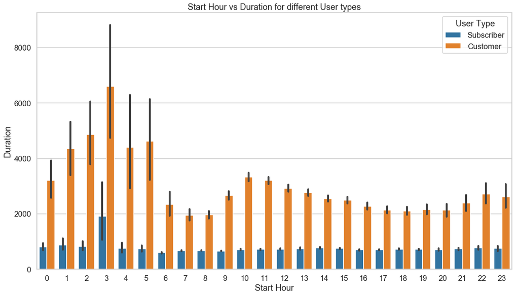

```python
plt.figure(figsize=[18,10])
sb.barplot(data=fgb,x='start_hour',y='duration_sec',hue='user_type');
plt.legend(title='User Type');
plt.xlabel('Start Hour');
plt.ylabel('Duration');
plt.title('Start Hour vs Duration for different User types');
```

### Question 21. Trends between duration and start hour for the different age groups using heat maps

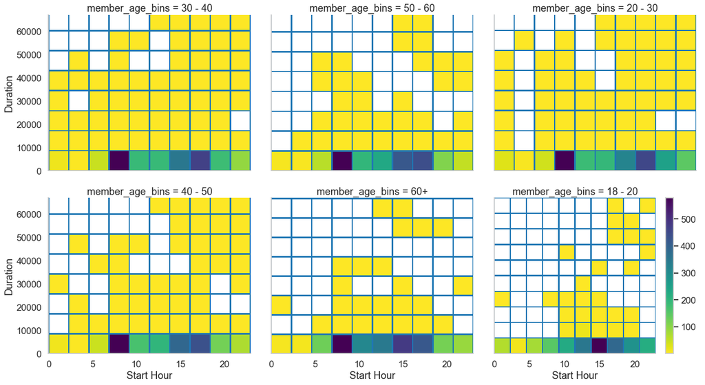

```python
plt.figure(figsize=[20,20])
g=sb.FacetGrid(data=fgb,col='member_age_bins',col_wrap=3,height=5,aspect=1.2)
g.map(plt.hist2d,'start_hour','duration_sec',cmin=0.1,cmap='viridis_r');
g.set_axis_labels("Start Hour", "Duration")
plt.colorbar()
```

### Question 22. Trends between duration and start month for different genders

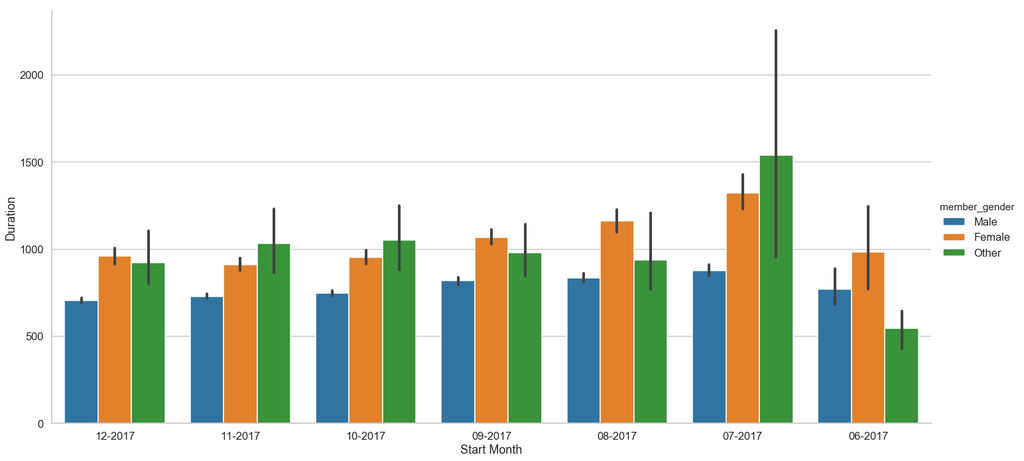

```python
plt.figure(figsize=[20,20])
g=sb.catplot(x="start_month_year",y="duration_sec",hue="member_gender",data=fgb,kind="bar",height=10,aspect=2)
g.set_axis_labels("Start Month", "Duration")
```

### Question 23. Trends between duration and start day for different user type with repect to age group

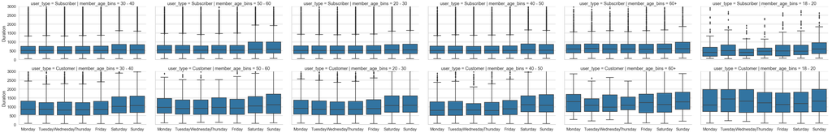

```python
plt.figure(figsize=[15,8])
g=sb.FacetGrid(data=fgb,col='member_age_bins',row='user_type',height=4,aspect=2,margin_titles=False)
g.map(sb.boxplot,'start_time_weekday','duration_sec');
g.set_axis_labels("", "Duration")
g.set(ylim=(0,3000))
plt.tight_layout()
```

# Reflection:

> There are some outliers in the age columns, few members are having age greater than 110.

> October'17 is the month in which maximum business for the Ford GoBike is done, in this particular data.

> Subscriber user type has 80% proportions

> Male gender members are about of 75% proportion.

> 20-40 is the most common age group of the members.

> In the month of july member of other gender took mean duration of more than 1500 seconds.

> Mean duration for the start hour 3 is highest.

> Customer user type use to have mean duration longer than subscriber user type.

> 260-460seconds is the most common duration time